# Aria_assignment1

Aria

2023-09-13

## Part0:

GitHub: https://github.com/LuLuAriaAria/727_assignment.git

## Part1:Reading data:

### 1.2. Read in the .dta version and store in an object called angell_stata.

```r
library("haven")
angell_stata <- read_dta("angell.dta")
```

### 1.3. Read in the .txt version and store it in an object called angell_txt.

```r
angell_txt <- read.table("angell.txt", header = F, sep = "")
```

### 1.4. What are the differences between angell_stata and angell_txt? Are there differences in the classes of the individual columns?

DTA files store structured data along with metadata, making them suitable for storing datasets with variables, labels, and data types. In `angell_dta`, we notice that every variable has its variable name. However, in TXT files, since TXT files do not include any built-in structure, and they are essentially just sequences of characters separated by delimiters, variable names are not included.

### 1.5. Make any updates necessary so that `angell_txt` is the same as `angell_stata`.

```r
library("dplyr")
angell_txt <- angell_txt %>% rename(city = V1, morint = V2,
                                     ethhet = V3, geomob = V4, region = V5)
```

### 1.6. Describe the Ethnic Heterogeneity variable. Use descriptive statistics such as mean, median, standard deviation, etc. How does it differ by region?

#### 1.6.1. descriptive statistics

```r
ethhet_describe <- function(x, na.omit = FALSE){
  if (na.omit)
  x <- x[!is.na(x)]
  eth_mean = mean(x)
  eth_median = median(x)
  eth_sd = sd(x)
  n = length(x)
  return(c(mean = eth_mean, median = eth_median, sd = eth_sd, n = n))
}
ethhet <- c("ethhet")
describe_stat <- sapply(angell_stata[ethhet], ethhet_describe)
describe_stat
```

```
##          ethhet
## mean   31.37209
## median 23.70000
## sd     20.41149
## n      43.00000
```

```r
describe_stat <- t(describe_stat)
describe_stat <- as.data.frame(describe_stat)
describe_stat
```

```
##            mean median       sd  n
## ethhet 31.37209   23.7 20.41149 43
```

#### 1.6.2. How does it differ by region?

```r
as.factor(angell_stata$region)
```

```
##  [1] E  E  E  E  MW E  E  MW E  MW MW W  MW MW E  MW MW W  E  MW MW MW W  MW W
## [26] W  MW MW W  S  S  S  S  S  S  S  S  S  S  S  S  S  S
## Levels: E MW S W
```

```r
describe_stat_group <- angell_stata %>% group_by(region) %>%
                                    summarise(mean_group = mean(ethhet),
                                              median_group = median(ethhet),
                                              sd_group = sd(ethhet),
                                              )
describe_stat_group
```

```
## # A tibble: 4 × 4
##   region mean_group median_group sd_group
##   <chr>       <dbl>        <dbl>    <dbl>
## 1 E            23.5         22.1    10.8
## 2 MW           21.7         19.2     9.08
## 3 S            52.5         53.8    21.4
## 4 W            16.5         16.1     4.16
```

If visualize it, that will be:

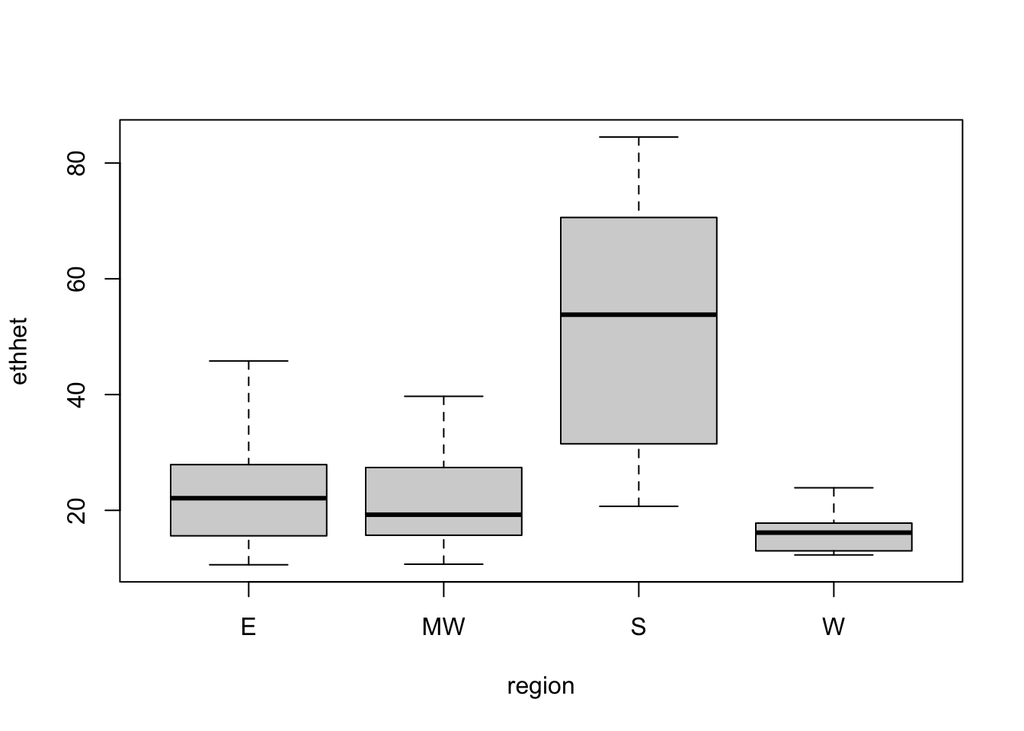

```r
plot_box <- boxplot(ethhet ~ region, data = angell_stata)
```

If we want to compare the differences in statistics between different regions, ANOVA is a good choice.Therefore, we need to check that if the variance is subject to normal distribution and the variance homogeneity.  
Histogram and Q-Q Plot are intuitive methods to verify the distribution:

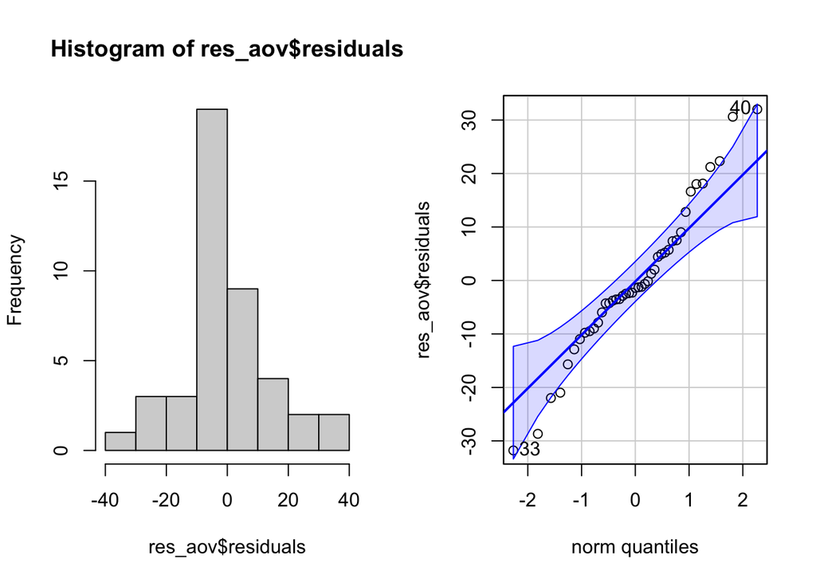

```r
par(mfrow = c(1,2))

res_aov <- aov(ethhet ~ region,
  data = angell_stata
)

plot_hist <- hist(res_aov$residuals)

library(car)
plot_norm <- qqPlot(res_aov$residuals)
```

From the histogram and QQ-plot above, we can already see that the normality assumption seems to be met. Indeed, the histogram roughly form a bell curve, indicating that the residuals follow a normal distribution. Furthermore, points in the QQ-plots roughly follow the straight line and most of them are within the confidence bands, also indicating that residuals follow approximately a normal distribution.  
To be conservative, we could also test the normality assumption via a normality test.

$H_0$:data come from a normal distribution  
$H_1$:data doesn’t come from a normal distribution

```r
shapiro.test(res_aov$residuals)
```

```
##
##  Shapiro-Wilk normality test
##
## data:  res_aov$residuals
## W = 0.97132, p-value = 0.3508
```

We notice that p-value = 0.35 >0.05, so we do not reject the hypothesis that residuals follow a normal distribution.  
The next step is to test the variance homogeneity.

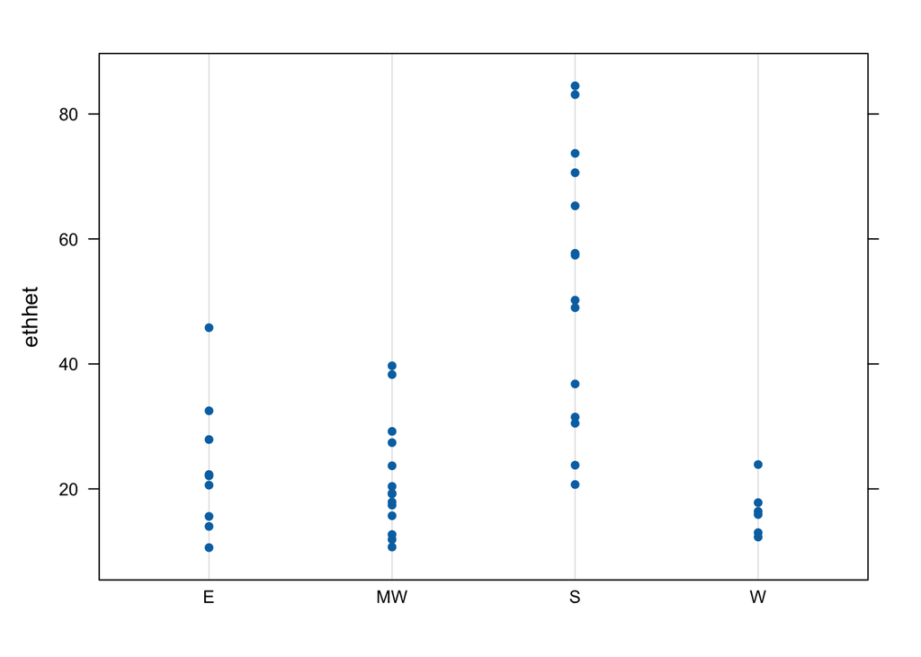

```r
library("lattice")

dotplot(ethhet ~ region,
  data = angell_stata
)
```

Obviously, the dispersion is more or less not the same between the different regions. Based on this, we assume that the variance of different groups is not subject to the hypothesis of variance homogeneity. To verify this assumption, we could utilize Levene test:  
$H_0$: variances are equal  
$H_1$: at least one variance is different

```r
leveneTest(ethhet ~ region,
  data = angell_stata
)
```

```
## Levene's Test for Homogeneity of Variance (center = median)
##       Df F value    Pr(>F)
## group  3  7.0311 0.0006846 ***
##       39
## ---
## Signif. codes:  0 '***' 0.001 '**' 0.01 '*' 0.05 '.' 0.1 ' ' 1
```

P = 0.00 < 0.05, indicating that we should reject the null hypothesis, and the variance between different groups are different.  
To summarize, since the variable is subject to normal distribution but it is not subject to variance homogeneity, we choose Welch ANOVA:

```r
ANOVA_eth <- oneway.test(ethhet ~ region,
  data = angell_stata,
  var.equal = FALSE
)
ANOVA_eth
```

```
##
##  One-way analysis of means (not assuming equal variances)
##
## data:  ethhet and region
## F = 11.725, num df = 3.000, denom df = 20.338, p-value = 0.0001119
```

p - value = 0.00 < 0.05, indicating that the Ethnic Heterogeneity is different among regions.

## Part2: Describing Data

### 2.7. Install the “MASS” package, load the package. Then, load the Boston dataset.

```r
library("MASS")
Boston <- MASS::Boston
```

### 2.8. What is the type of the Boston object?

```r
typeof(Boston)
```

```
## [1] "list"
```

### 2.9.What is the class of the Boston object?

```r
class(Boston)
```

```
## [1] "data.frame"
```

### 2.10 How many of the suburbs in the Boston data set bound the Charles river?

```r
by_river <- sum(Boston$chas)
by_river
```

```
## [1] 35
```

### 2.11. Do any of the suburbs of Boston appear to have particularly high crime rates? Tax rates? Pupil-teacher ratios? Comment on the range of each variable.

```r
variable_boston <- Boston[c("crim","tax","ptratio")]
table_var_range <- variable_boston %>%
                    apply(2,summary) %>%
                    t() %>%
                  as_tibble() %>%
                  mutate(
                    range = paste0("[", Min., ",", Max., "]")
                  )
table_var_range <- as.data.frame(table_var_range)
table_var_range$name <- c("crim","tax","ptratio")

table_var_range <- table_var_range[c("name","range")]
table_var_range
```

```
##      name             range
## 1    crim [0.00632,88.9762]
## 2     tax         [187,711]
## 3 ptratio         [12.6,22]
```

### 2.12. Describe the distribution of pupil-teacher ratio among the towns in this data set that have a per capita crime rate larger than 1. How does it differ from towns that have a per capita crime rate smaller than 1?

```r
ptratio_1 <- dplyr::filter(Boston, Boston$crim > 1)
ptratio_2 <- dplyr::filter(Boston, Boston$crim < 1)

Boston_new <- mutate(Boston, group = ifelse(crim>1,1,0))
```

Visualization:

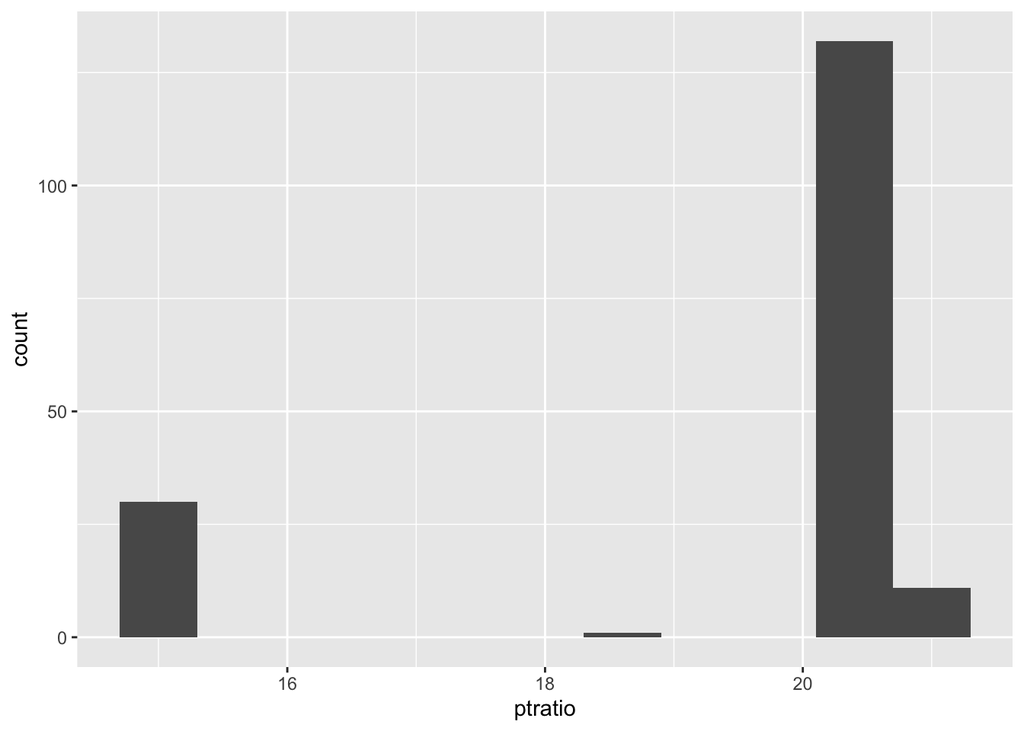

```r
library(ggplot2)

histplot1 <- ggplot(ptratio_1, aes(ptratio)) +
                geom_histogram(binwidth = 0.6)

histplot1
```

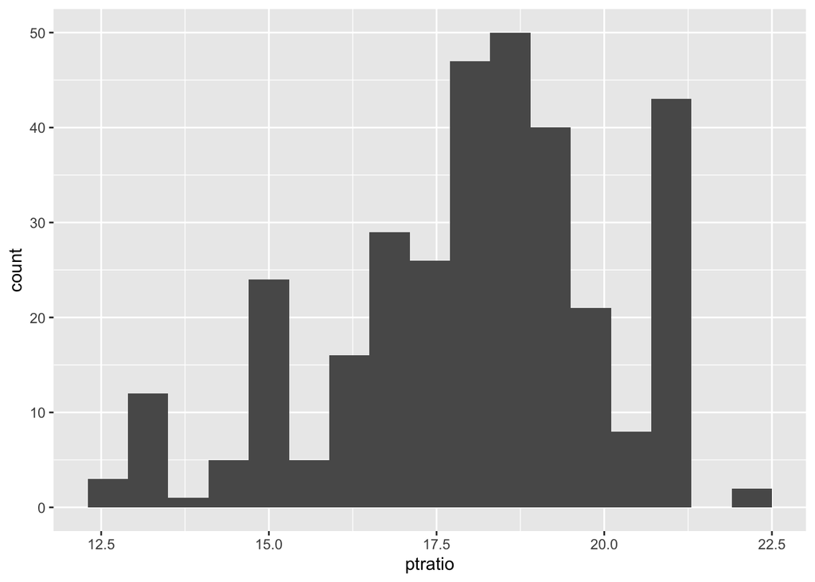

```r
histplot2 <- ggplot(ptratio_2, aes(ptratio)) +
                geom_histogram(binwidth = 0.6)

histplot2
```

Descriptive statistics:

```r
ptratio_describe <- function(x, na.omit = FALSE){
  if (na.omit)
  x <- x[!is.na(x)]
  ptr_mean = mean(x)
  ptr_median = median(x)
  ptr_sd = sd(x)
  n = length(x)
  return(c(mean = ptr_mean, median = ptr_median, sd = ptr_sd, n = n))
}

describe_stat_ptr1 <- sapply(ptratio_1["ptratio"], ptratio_describe)
describe_stat_ptr2 <- sapply(ptratio_2["ptratio"], ptratio_describe)

describe_stat_ptr1 <- as.data.frame(describe_stat_ptr1)
describe_stat_ptr2 <- as.data.frame(describe_stat_ptr2)

ptratio_crime <- cbind(describe_stat_ptr1, describe_stat_ptr2)
colnames(ptratio_crime) <- c("crime_higher","crime_lower")

ptratio_crime
```

```
##        crime_higher crime_lower
## mean      19.294253   18.015964
## median    20.200000   18.300000
## sd         2.117576    2.059995
## n        174.000000  332.000000
```

In order to compare two groups, we need to check the distribution and variance of data:

```r
shapiro.test(ptratio_1$ptratio)
```

```
##
##  Shapiro-Wilk normality test
##
## data:  ptratio_1$ptratio
## W = 0.51756, p-value < 2.2e-16
```

```r
shapiro.test(ptratio_2$ptratio)
```

```
##
##  Shapiro-Wilk normality test
##
## data:  ptratio_2$ptratio
## W = 0.96226, p-value = 1.453e-07
```

```r
res.ftest <- var.test(ptratio ~ group, data = Boston_new)
res.ftest
```

```
##
##  F test to compare two variances
##
## data:  ptratio by group
## F = 0.94636, num df = 331, denom df = 173, p-value = 0.6671
## alternative hypothesis: true ratio of variances is not equal to 1
## 95 percent confidence interval:
##  0.7252251 1.2216574
## sample estimates:
## ratio of variances
##          0.9463558
```

In shapiro test, p < 0.05, so we could conclude that two groups are not subject to normal distribution. In F-test, p > 0.05, therefore, we choose non parametric two sample Wilcoxon rank test:

```r
res <- wilcox.test(ptratio ~ group, data = Boston_new, var.equal = TRUE)
res
```

```
##
##  Wilcoxon rank sum test with continuity correction
##
## data:  ptratio by group
## W = 16256, p-value = 3.005e-16
## alternative hypothesis: true location shift is not equal to 0
```

p < 0.05, therefore, the pupil-teacher ratio between two groups are significantly different.

## Part3. Writing functions

### 3.13. Write a function that calculates 95% confidence intervals for a point estimate. The function should be called my_CI. When called with my_CI(2, 0.2), the function should print out “The 95% CI upper bound of point estimate 2 with standard error 0.2 is 2.392. The lower bound is 1.608.”

```r
my_CI <- function(x, y){
  CI_upper <- x + 1.96*y
  CI_lower <- x - 1.96*y
  res_CI <- paste0("The 95% CI upper bound of point estimate",x,
                   "with standard error",CI_upper,".",
                   "The lower bound is",CI_lower,".")
  return(res_CI)
}
my_CI(2,0.2)
```

```
## [1] "The 95% CI upper bound of point estimate2with standard error2.392.The lower bound is1.608."
```

### 3.14.Create a new function called my_CI2 that does that same thing as the my_CI function but outputs a vector of length 2 with the lower and upper bound of the confidence interval instead of printing out the text. Use this to find the 95% confidence interval for a point estimate of 0 and standard error 0.4.

```r
my_CI2 <- function(x,y){
    CI_upper_2 <- x + 1.96*y
    CI_lower_2 <- x - 1.96*y
    res_CI_2 <- c(CI_lower_2,CI_upper_2)
    return(res_CI_2)
}
```

### 3.15. Update the my_CI2 function to take any confidence level instead of only 95%. Call the new function my_CI3. You should add an argument to your function for confidence level.

```r
my_CI3 <- function(x,y,alpha){
  alpha <- qnorm(1-alpha/2)
  CI_upper_3 <- x + alpha * y
  CI_lower_3 <- x - alpha * y
  res_CI_3 <- c(CI_lower_3,CI_upper_3)
    return(res_CI_3)
}
```

### 3.16. Without hardcoding any numbers in the code, find a 99% confidence interval for Ethnic Heterogeneity in the Angell dataset. Find the standard error by dividing the standard deviation by the square root of the sample size.

```r
CI_lower_4 <- t.test(angell_stata$ethhet,conf = 0.99)$conf.int[1]
CI_upper_4 <- t.test(angell_stata$ethhet,conf = 0.99)$conf.int[2]
res_CI_4 <- c(CI_lower_4,CI_upper_4)
res_CI_4
```

```
## [1] 22.97376 39.77042
```

```r
se <- sd(angell_stata$ethhet)/sqrt(length(angell_stata$ethhet))
se
```

```
## [1] 3.112722
```

### 3.17. Write a function that you can apply to the Angell dataset to get 95% confidence intervals. The function should take one argument: a vector. Use if-else statements to output NA and avoid error messages if the column in the data frame is not numeric or logical.

```r
my_CI5 <- function(x){
  if (is.character(x) == TRUE){
    print("NA")
  } else {
    my_CI_lower_5 <- t.test(x,conf=0.95)$conf.int[1]
    my_CI_upper_5 <- t.test(x,conf=0.95)$conf.int[2]
    res_CI_5 <- c(my_CI_lower_5,my_CI_upper_5)
    return(res_CI_5)
  }
}
```